# Home advantage in Fantasy Premier League - Notebook

**Jerome Williams**  
**March 3, 2024**

Back to jeromewilliams.net.

## Preamble

First, let’s load some packages and define some helpers we will use later.

```r
library(tidyverse)
```

```r
library(ggplot2)
library(plotrix)

source_string <- 'Source: https://github.com/vaastav/Fantasy-Premier-League; Jerome Williams'

theme_jw <- function() {
  theme_bw() +
    theme(
      plot.title = element_text(face = 'bold', hjust = 0.5),
      plot.subtitle = element_text(hjust = 0.5),
      plot.caption = element_text(hjust = 0)
    )
}
```

## Preparing the data

### Fantasy Premier League data

We will use data from the [Fantasy Premier League data](https://github.com/vaastav/Fantasy-Premier-League) project, which I downloaded previously. The data is stored season by season, so we have to combine seasons. Data on each player/gameweek (such as total points scored) are saved in `merged_gw.csv`. Player/gameweek data for 2016/17 through 2019/20 does not include player position data (e.g., defender, midfielder, etc.) Since we will need player position data later, we also merge `merged_gw.csv` with `players_raw.csv` (which does contain player position data) for seasons 2016/17 through 2019/20.

```r
fpl_data_path <- 'data/Fantasy-Premier-League-master/data/'

load_and_merge_player_and_gameweek_data <- function(season_str) {
  season_string_dash <- str_replace(season_str, '/', '-')
  merged_gw <- read_csv(paste0(fpl_data_path, season_string_dash, '/gws/merged_gw.csv'),
                        show_col_types = FALSE) %>% mutate(season = season_str)
  players_raw <- read_csv(paste0(fpl_data_path, season_string_dash, '/players_raw.csv'),
                          show_col_types = FALSE)
  player_position_data <- players_raw %>% select(id, element_type)
  gameweek_data <- merged_gw %>%
    left_join(player_position_data, by = c('element' = 'id')) %>%
    mutate(position = case_when(element_type == 1 ~ 'GK',
                              element_type == 2 ~ 'DEF',
                              element_type == 3 ~ 'MID',
                              element_type == 4 ~ 'FWD')
  )
}
load_gameweek_data <- function(season_str) {
  season_string_dash <- str_replace(season_str, '/', '-')
  merged_gw <- read_csv(paste0(fpl_data_path, season_string_dash, '/gws/merged_gw.csv'),
                        show_col_types = FALSE) %>% mutate(season = season_str) %>%
    mutate(position = if_else(position == 'GKP', 'GK', position))
}

seasons <- list()
seasons[['2016/17']] <- load_and_merge_player_and_gameweek_data(season_str = '2016/17')
seasons[['2017/18']] <- load_and_merge_player_and_gameweek_data(season_str = '2017/18')
seasons[['2018/19']] <- load_and_merge_player_and_gameweek_data(season_str = '2018/19')
seasons[['2019/20']] <- load_and_merge_player_and_gameweek_data(season_str = '2019/20')
seasons[['2020/21']] <- load_gameweek_data(season_str = '2020/21')
seasons[['2021/22']] <- load_gameweek_data(season_str = '2021/22')
seasons[['2022/23']] <- load_gameweek_data(season_str = '2022/23')
gw <- bind_rows(seasons)
```

As a check, let’s see how many observations we have in our combined dataset.

```r
print(nrow(gw))
```

```
## [1] 166813
```

We have 166,813 observations (player/gameweek pairs).

Let’s ensure we have position data for all observations.

```r
any_without_position_data <- gw$position %>% is.na() %>% any()
print(any_without_position_data)
```

```
## [1] FALSE
```

As a check, let’s plot the number of observations per season.

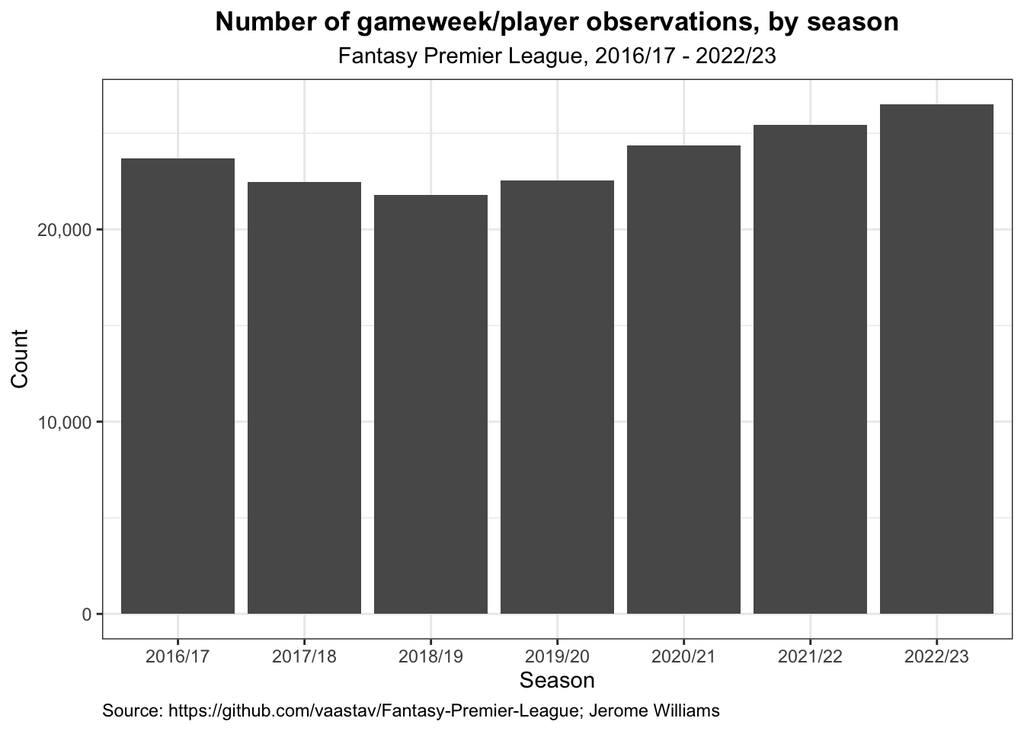

```r
ggplot(gw) +
  geom_bar(aes(x = season)) +
  scale_y_continuous(labels = scales::number_format(big.mark = ",")) +
  theme_jw() +
  labs(title = 'Number of gameweek/player observations, by season',
       subtitle = 'Fantasy Premier League, 2016/17 - 2022/23',
       x = 'Season',
       y = 'Count',
       caption = source_string)
```

Let’s also check the number of distinct gameweeks per season. We should have 38 gameweeks per season.

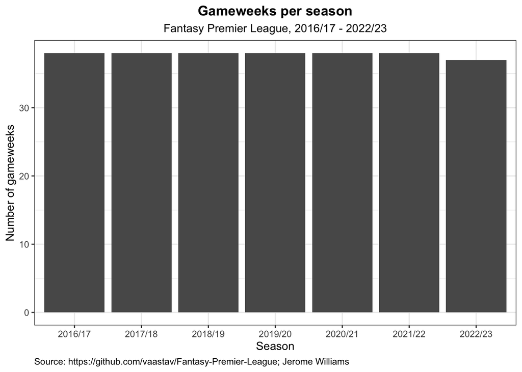

```r
by_season <- gw %>% group_by(season) %>% summarize(n_gameweeks = n_distinct(GW))
ggplot(by_season) + geom_col(aes(x = season, y = n_gameweeks)) +
  theme_jw() +
  labs(
    title = 'Gameweeks per season',
    subtitle = 'Fantasy Premier League, 2016/17 - 2022/23',
    x = 'Season',
    y = 'Number of gameweeks',
    caption = source_string
  )
```

### Team level data from football-data.co.uk

Our FPL data does not have *team-level* results for every season we are interested in, so we’ll also use data from www.football-data.co.uk. Let’s load this data as well.

```r
fd_data_path <- 'data/footballdata_co_uk/';

load_fd_data <- function(season_string) {
  season_no_slash <- str_replace(season_string, '/', '') %>% str_replace('20', '')
  season <- read_csv(
    paste0(fd_data_path, 'E0_', season_no_slash, '.csv'),
    show_col_types = FALSE
    ) %>%
    mutate(season = season_string)
}

season_strings <- c('2016/17',
                    '2017/18',
                    '2018/19',
                    '2019/20',
                    '2020/21',
                    '2021/22',
                    '2022/23')

fd <- lmap(season_strings, load_fd_data) %>%
  bind_rows()
```

## Team-level home advantage

Before we consider home advantage in FPL points for individual players, let’s confirm that we see home advantage in team-level outcomes. Specifically, let’s plot the average *win rate* and average *goals scored* for Premier League teams playing at home and playing away between 2016/17 and 2022/23.

Because the data has a single row for each match (with e.g. home goals and away goals stored in separate fields), let’s reshape our dataset so that we have a single row for each match-team observation (i.e., two rows per match, with the `home_away` field indicating ‘Home’ or ‘Away’).

```r
fd_home <- fd %>% select(season,
                      date = Date,
                      team = HomeTeam,
                      opponent = AwayTeam,
                      goals_scored = FTHG, # full time home goals
                      goals_conceded = FTAG, # full time away goals
                      FTR) %>%
  mutate(home_away = 'Home',
         result = case_when(FTR == 'H' ~ 'W', # full time result
                            FTR == 'A' ~ 'L',
                            FTR == 'D' ~ 'D'),
         win = (result == 'W'))
fd_away <- fd %>% select(season,
                      date = Date,
                      team = AwayTeam,
                      opponent = HomeTeam,
                      goals_scored = FTAG,
                      goals_conceded = FTHG,
                      FTR) %>%
  mutate(home_away = 'Away',
         result = case_when(FTR == 'H' ~ 'L',
                            FTR == 'A' ~ 'W',
                            FTR == 'D' ~ 'D'),
         win = (result == 'W'))

fd2 <- bind_rows(fd_home, fd_away)
```

### Team-level home advantage in win rate

Now that we’ve have created our home/away dataset, let’s plot the mean win rate, by season and by home/away.

```r
win_rate_stats <- fd2 %>%
  group_by(season, home_away) %>%
  summarize(mean = mean(win),
            se = std.error(win),
            n = n()) %>%
  mutate(home_away = fct_relevel(home_away, 'Home', 'Away'))
```

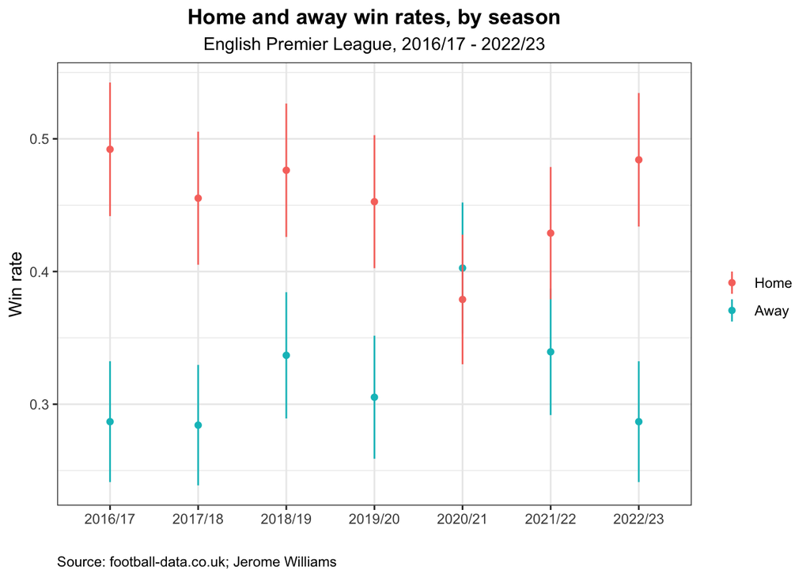

```r
ggplot(win_rate_stats, aes(x = season, color = home_away)) +
  geom_point(aes(y = mean)) +
  geom_linerange(aes(ymin = mean - 1.96 * se,
                     ymax = mean + 1.96 * se)) +
  theme_jw() +
  labs(
    title = 'Home and away win rates, by season',
    subtitle = 'English Premier League, 2016/17 - 2022/23',
    color = '',
    x = '',
    y = 'Win rate',
    caption = 'Source: football-data.co.uk; Jerome Williams'
  )
```

Interestingly, we see that home advantage disappeared completely in the 2020/21 season. Because of the COVID-19 pandemic, part of 2020/21 Premier League season was played behind closed doors, i.e., with no supporters in stadiums ([premierleague.com](https://www.premierleague.com/news/1680761)), and part was played with only a limited number of supporters in stadiums ([wikipedia](https://en.wikipedia.org/wiki/2020–21_Premier_League)).

It is well documented that the behind-closed-doors 2020/21 season resulted in diminished home advantage (link)[https://www.sciencedirect.com/science/article/pii/S146902922100131X]. Indeed, the natural experiment created by the COVID-19 pandemic has provided insight into the sources of home advantage. In their [2021 article in *Psychology of Sport & Exercise*](https://www.sciencedirect.com/science/article/pii/S146902922100131X), Merrick, Bilalic, Neave, and Wolfson find that the diminished home advantage in behind-closed-doors matches provides support for the theory that home advantage stems from (i) the home crowd’s effect on the home team’s performacne, and (ii) the home crowd’s effect on the referee. After the 2020/21 season, alternative possible explanations, such as the effects of travel on the away team’s performance, seem less likely.

In our data, we also see that home advantage is also smaller in the 2021/22 season, when supporters were allowed back into stadiums. As far as I know, there is no good explanation for why home advantage was diminished in 2021/22.

Apart from 2020/21 and 2021/22, home advantage in other seasons is pronounced and fairly consistent. Home win rates tend to be between 0.45 to 0.5, while away win rates tend to be between approximately 0.28 and 0.35.

### Team-level home advantage in goals scored

Let’s check whether home advantage also shows up in goals scored. It should, given the likely high correlation between goals scored and win rate.

```r
win_rate_stats <- fd2 %>%
  group_by(season, home_away) %>%
  summarize(mean = mean(goals_scored),
            se = std.error(goals_scored),
            n = n()) %>%
  mutate(home_away = fct_relevel(home_away, 'Home', 'Away'))
```

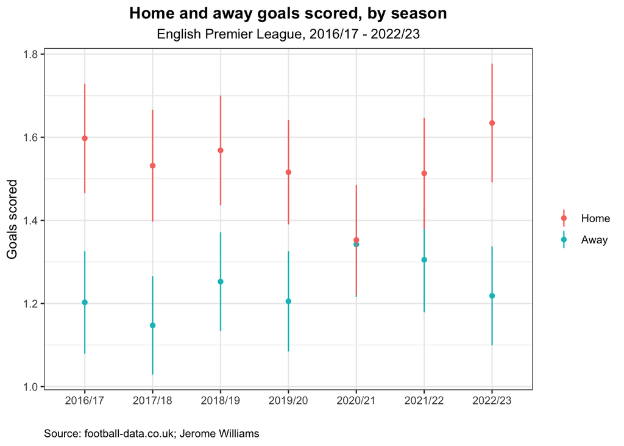

```r
ggplot(win_rate_stats, aes(x = season, color = home_away)) +
  geom_point(aes(y = mean)) +
  geom_linerange(aes(ymin = mean - 1.96 * se,
                     ymax = mean + 1.96 * se)) +
  theme_jw() +
  labs(
    title = 'Home and away goals scored, by season',
    subtitle = 'English Premier League, 2016/17 - 2022/23',
    color = '',
    x = '',
    y = 'Goals scored',
    caption = 'Source: football-data.co.uk; Jerome Williams'
  )
```

Indeed, we see a similar home advantage in goals scored, with the effect disappearing in 2020/21 and smaller in 2021/22. As the plot above shows, outside of 2020/21 and 2021/22, home teams score an average of 1.5-1.6 goals per match while away teams score an average of 1.15-1.25 goals per match.

## Player-level home advantage

Now that we’ve confirmed that home advantage obtains at the team-level, let’s turn to our question of interest: do players playing at home score more FPL points on average than players playing away?

To answer this question, we’ll start using the Fantasy Premier League dataset.

### Filtering to FPL-relevant players

The FPL game includes a complete squad for each Premier League team every season. However, a team’s complete squad typically includes several players who end up playing only a small number of minutes over the course of a season and who therefore tend not to be relevant to FPL. We want to exclude these players from the analysis since they will generally score zero points, whether or not their team plays at home or away. We want to focus instead on the players whom FPL managers would actually select.

To restrict to game-relevant players, I opt to filter to players who are selected by at least 0.5% of managers in the relevant gameweek.

Let’s check whether this filtering is sensible. Let’s plot the average minutes played and average FPL points among included and excluded observations, using the 0.5% selection rate exclusion criteria.

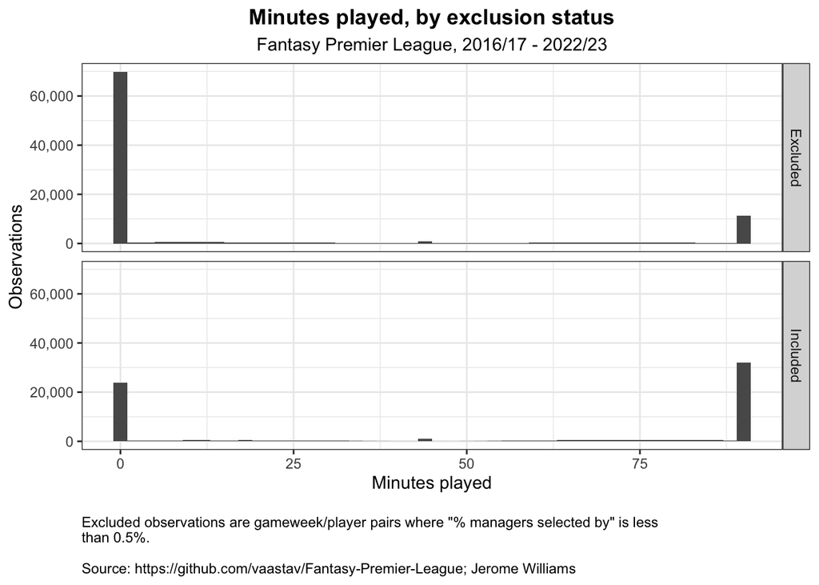

```r
gw_check <- gw %>%
  mutate(included = if_else(pct_selected >= 0.005, 'Included', 'Excluded'))

ggplot(gw_check) +
  geom_histogram(aes(x = minutes), binwidth = 2) +
  facet_grid(included ~ .) +
  theme_jw() +
  scale_y_continuous(labels = scales::comma_format()) +
  labs(title = 'Minutes played, by exclusion status',
       subtitle = 'Fantasy Premier League, 2016/17 - 2022/23',
       y = 'Observations',
       x = 'Minutes played',
       caption = '
Excluded observations are gameweek/player pairs where "% managers selected by" is less \nthan 0.5%.

Source: https://github.com/vaastav/Fantasy-Premier-League; Jerome Williams')
```

The plot confirms shows that, if we exclude player/gameweek observation with selection rates less than 0.5%, the players excluded are mostly (but not all) players playing zero minutes in the relevant gameweek. Many *included* players also play zero minutes, but that is to be expected: there is nothing stopping a player who is highly-selected in particular gameweek from playing zero minutes, whether because of injury or squad rotation or some other reason.

For the sake of completeness, let’s also compare FPL points scored for included/excluded observations.

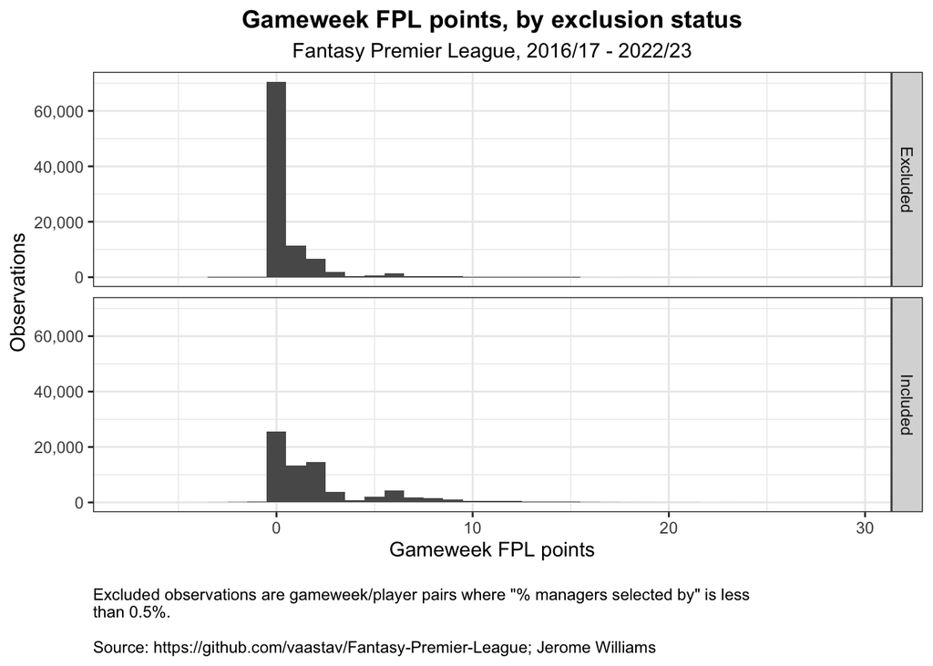

```r
gw_check <- gw %>%
  mutate(included = if_else(pct_selected >= 0.005, 'Included', 'Excluded'))

ggplot(gw_check) +
  geom_histogram(aes(x = total_points), binwidth = 1) +
  facet_grid(included ~ .) +
  theme_jw() +
  scale_y_continuous(labels = scales::comma_format()) +
  labs(title = 'Gameweek FPL points, by exclusion status',
       subtitle = 'Fantasy Premier League, 2016/17 - 2022/23',
       y = 'Observations',
       x = 'Gameweek FPL points',
       caption = '
Excluded observations are gameweek/player pairs where "% managers selected by" is less \nthan 0.5%.

Source: https://github.com/vaastav/Fantasy-Premier-League; Jerome Williams')
```

As expected, excluded observations are more than included observations likely to score zero FPL points than included observations.